# WDI Trends

This example is adapted from https://datavizm20.classes.andrewheiss.com/example/09-example/.

For this example, we’re going to use cross-national data from the [World Bank’s Open Data portal](https://data.worldbank.org/). You can download the data with the [**WDI** package](https://cran.r-project.org/web/packages/WDI/index.html).

For efficiency, you could skip the data downloading and use a precompiled dataset:

- [`wdi_co2.csv`](https://datavizm20.classes.andrewheiss.com/data/wdi_co2.csv)

## Did Countries’ Relative CO<sub>2</sub> Emissions Performance Change Over Time?

From the 1990s through the 2010s, increasing global and political attention was paid to reducing carbon emissions to combat climate change. During this time, did some countries do substantially better and reduce their emissions more than their peers?

To answer this question, we will use a dataset compiled from the World Bank’s World Development Indicators.

### Load data

First, we load the libraries we’ll be using:

```r
library(tidyverse)  # For ggplot, dplyr, and friends
library(ggrepel)    # For non-overlapping labels
library(ggtext)     # For fancier text handling
```

```r
# This is an example of how to pull data from the WDI package.
indicators <- c("SP.POP.TOTL",     # Population
                "EN.ATM.CO2E.PC",  # CO2 emissions
                "NY.GDP.PCAP.KD")  # GDP per capita

wdi_co2_raw <- WDI::WDI(
  country = "all",
  indicator = indicators,
  extra = TRUE,

  start = 1995,
  end = 2015
)
```

Then we clean the data by removing non-country countries and renaming some of the columns.

```r
wdi_clean <- wdi_co2_raw %>%
  filter(region != "Aggregates") %>%
  select(iso2c, iso3c, country, year,
         population = SP.POP.TOTL,
         co2_emissions = EN.ATM.CO2E.PC,
         gdp_per_cap = NY.GDP.PCAP.KD,
         region, income)
```

### Clean and reshape data

Next we’ll do some substantial filtering and reshaping so that we can end up with the rankings of CO<sub>2</sub> emissions in 1995 and 2014. I annotate as much as possible below so you can see what’s happening in each step.

```r
co2_rankings <- wdi_clean %>%
  # Get rid of smaller countries
  filter(population > 200000) %>%
  # Only look at two years
  filter(year %in% c(1995, 2014)) %>%
  # Get rid of all the rows that have missing values in co2_emissions
  drop_na(co2_emissions) %>%
  # Look at each year individually and rank countries based on their emissions that year
  group_by(year) %>%
  mutate(ranking = rank(co2_emissions)) %>%
  ungroup() %>%
  # Only select a handful of columns, mostly just the newly created "ranking"
  # column and some country identifiers
  select(iso3c, country, year, region, income, ranking) %>%
  # Right now the data is tidy and long, but we want to widen it and create
  # separate columns for emissions in 1995 and in 2014. pivot_wider() will make
  # new columns based on the existing "year" column (that's what `names_from`
  # does), and it will add "rank_" as the prefix, so that the new columns will
  # be "rank_1995" and "rank_2014". The values that go in those new columns will
  # come from the existing "ranking" column
  pivot_wider(names_from = year,
              names_prefix = "rank_",
              values_from = ranking) %>%
  # Find the difference in ranking between 2014 and 1995
  mutate(rank_diff = rank_2014 - rank_1995) %>%
  # Remove all rows where there's a missing value in the rank_diff column
  drop_na(rank_diff) %>%
  # Make an indicator variable that is true of the absolute value of the
  # difference in rankings is greater than 25. 25 is arbitrary here—that just
  # felt like a big change in rankings
  mutate(big_change = if_else(abs(rank_diff) >= 25, TRUE, FALSE)) %>%
  # Make another indicator variable that indicates if the rank improved by a
  # lot, worsened by a lot, or didn't change much. We use the case_when()
  # function, which is like a fancy version of ifelse() that takes multiple
  # conditions. This is how it generally works:
  #
  # case_when(
  #  some_test ~ value_if_true,
  #  some_other_test ~ value_if_true,
  #  TRUE ~ value_otherwise
  #)
  mutate(big_change_label = case_when(
    rank_diff <= -25 ~ "Rank improved",
    rank_diff >= 25 ~ "Rank worsened",
    TRUE ~ "Rank changed a little"
  ))
```

Here’s what that reshaped data looked like before:

```r
head(wdi_clean)
```

```
## # A tibble: 6 x 9
##   iso2c iso3c country  year population co2_emissions gdp_per_cap region                income
##   <chr> <chr> <chr>   <dbl>      <dbl>         <dbl>       <dbl> <chr>                 <chr>
## 1 AD    AND   Andorra  2015      78011         NA         41768. Europe & Central Asia High income
## 2 AD    AND   Andorra  2004      76244          7.36      47033. Europe & Central Asia High income
## 3 AD    AND   Andorra  2001      67341          7.79      41421. Europe & Central Asia High income
## 4 AD    AND   Andorra  2002      70049          7.59      42396. Europe & Central Asia High income
## 5 AD    AND   Andorra  2014      79213          5.83      40790. Europe & Central Asia High income
## 6 AD    AND   Andorra  1995      63850          6.66      32918. Europe & Central Asia High income
```

And here’s what it looks like now:

```r
head(co2_rankings)
```

```
## # A tibble: 6 x 9
##   iso3c country              region                     income              rank_1995 rank_2014 rank_diff big_change big_change_label
##   <chr> <chr>                <chr>                      <chr>                   <dbl>     <dbl>     <dbl> <lgl>      <chr>
## 1 ARE   United Arab Emirates Middle East & North Africa High income               167       171         4 FALSE      Rank changed a little
## 2 AFG   Afghanistan          South Asia                 Low income                  8        24        16 FALSE      Rank changed a little
## 3 ALB   Albania              Europe & Central Asia      Upper middle income        54        78        24 FALSE      Rank changed a little
## 4 ARM   Armenia              Europe & Central Asia      Upper middle income        71        76         5 FALSE      Rank changed a little
## 5 AGO   Angola               Sub-Saharan Africa         Lower middle income        59        61         2 FALSE      Rank changed a little
## 6 ARG   Argentina            Latin America & Caribbean  High income               103       119        16 FALSE      Rank changed a little
```

### Plot the data and annotate

I use the FiraGO font in this plot. You can download it from [here](https://github.com/bBoxType/FiraGO/releases/latest). You can download many other nice fonts from Google Fonts. Another nice one is [IBM Plex Sans](https://fonts.google.com/specimen/IBM+Plex+Sans).

[output not shown]

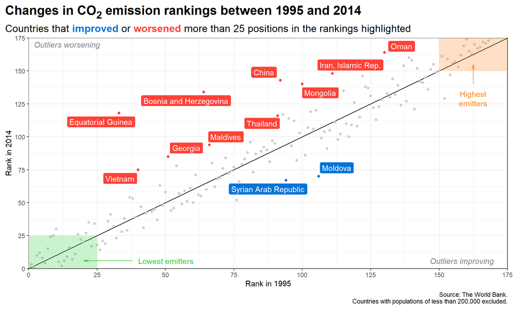

```r
# These three functions make it so all geoms that use text, label, and
# label_repel will use Comic Sans as the font. Those layers are *not*
# influenced by whatever you include in the base_family argument in something
# like theme_bw(), so ordinarily you'd need to specify the font in each
# individual annotate(geom = "text") layer or geom_label() layer, and that's
# tedious! This removes that tediousness.
update_geom_defaults("text", list(family = "FiraGO"))
update_geom_defaults("label", list(family = "FiraGO"))
update_geom_defaults("label_repel", list(family = "FiraGO"))

ggplot(co2_rankings) +
    aes(x = rank_1995, y = rank_2014) +
  # Add a reference line that goes from the bottom corner to the top corner
  annotate(geom = "segment", x = 0, xend = 175, y = 0, yend = 175) +
  # Add points and color them by the type of change in rankings
  geom_point(aes(color = big_change_label)) +
  # Add repelled labels. Only use data where big_change is TRUE. Fill them by
  # the type of change (so they match the color in geom_point() above) and use
  # white text
  geom_label_repel(data = filter(co2_rankings, big_change == TRUE),
                   aes(label = country, fill = big_change_label),
                   color = "white") +
  # Add notes about what the outliers mean in the bottom left and top right
  # corners. These are italicized and light grey. The text in the bottom corner
  # is justified to the right with hjust = 1, and the text in the top corner is
  # justified to the left with hjust = 0
  annotate(geom = "text", x = 170, y = 6, label = "Outliers improving",
           fontface = "italic", hjust = 1, color = "grey50") +
  annotate(geom = "text", x = 2, y = 170, label = "Outliers worsening",
           fontface = "italic", hjust = 0, color = "grey50") +
  # Add mostly transparent rectangles in the bottom right and top left corners
  annotate(geom = "rect", xmin = 0, xmax = 25, ymin = 0, ymax = 25,
           fill = "#2ECC40", alpha = 0.25) +
  annotate(geom = "rect", xmin = 150, xmax = 175, ymin = 150, ymax = 175,
           fill = "#FF851B", alpha = 0.25) +
  # Add text to define what the rectangles above actually mean. The \n in
  # "highest\nemitters" will put a line break in the label
  # Note: if you use geom_richtext() or geom_textbox() for markdown support
  # use <br> instead of \n for line breaks
  annotate(geom = "text", x = 40, y = 6, label = "Lowest emitters",
           hjust = 0, color = "#2ECC40") +
  annotate(geom = "text", x = 162.5, y = 135, label = "Highest\nemitters",
           hjust = 0.5, vjust = 1, lineheight = 1, color = "#FF851B") +
  # Add arrows between the text and the rectangles. These use the segment geom,
  # and the arrows are added with the arrow() function, which lets us define the
  # angle of the arrowhead and the length of the arrowhead pieces. Here we use
  # 0.5 lines, which is a unit of measurement that ggplot uses internally (think
  # of how many lines of text fit in the plot). We could also use unit(1, "cm")
  # or unit(0.25, "in") or anything else
  annotate(geom = "segment", x = 38, xend = 20, y = 6, yend = 6, color = "#2ECC40",
           arrow = arrow(angle = 15, length = unit(0.5, "lines"))) +
  annotate(geom = "segment", x = 162.5, xend = 162.5, y = 140, yend = 155, color = "#FF851B",
           arrow = arrow(angle = 15, length = unit(0.5, "lines"))) +
  # Use three different colors for the points
  scale_color_manual(values = c("grey80", "#0074D9", "#FF4136"),
                     aesthetics = c("color", "fill")) +
  # Make the x and y axes expand all the way to the edges of the plot area and
  # add breaks every 25 units from 0 to 175
  scale_x_continuous(expand = c(0, 0), breaks = seq(0, 175, 25)) +
  scale_y_continuous(expand = c(0, 0), breaks = seq(0, 175, 25)) +
  # Add labels! There are a couple fancy things here.
  # 1. In the title we wrap the 2 of CO2 in the HTML <sub></sub> tag so that the
  #    number gets subscripted. The only way this will actually get parsed as
  #    HTML is if we tell the plot.title to use element_markdown() in the
  #    theme() function, and element_markdown() comes from the ggtext package.
  # 2. In the subtitle we bold the two words **improved** and **worsened** using
  #    Markdown asterisks. We also wrap these words with HTML span tags with
  #    inline CSS to specify the color of the text. Like the title, this will
  #    only be processed and parsed as HTML and Markdown if we tell the p
  #    lot.subtitle to use element_markdown() in the theme() function.
  labs(x = "Rank in 1995", y = "Rank in 2014",
       title = "Changes in CO<sub>2</sub> emission rankings between 1995 and 2014",
       subtitle = "Countries that <span style='color: #0074D9'>**improved**</span> or <span style='color: #FF4136'>**worsened**</span> more than 25 positions in the rankings highlighted",
       caption = "Source: The World Bank.\nCountries with populations of less than 200,000 excluded.") +
  # Turn off the legends for color and fill, since the subtitle includes that
  guides(color = guide_none(), fill = guide_none()) +
  # Use theme_bw() with FiraGo
  theme_bw(base_family = "FiraGO") +
  # Tell the title and subtitle to be treated as Markdown/HTML, make the title
  # 1.6x the size of the base font, and make the subtitle 1.3x the size of the
  # base font. Also add a little larger margin on the right of the plot so that
  # the 175 doesn't get cut off.
  theme(plot.title = element_markdown(face = "bold", size = rel(1.6)),
            plot.title.position = "plot",
        plot.subtitle = element_markdown(size = rel(1.3)),
        plot.margin = unit(c(0.5, 1, 0.5, 0.5), units = "lines")
            )
```

Overall, based on these data, there appears to be substantial stability in relative CO<sub>2</sub> emissions across countries between 1995 and 2014. Despite this strong overall trend, there were some countries, such as Moldova, that substantially improved their relative emissions. Other countries, particularly those that were rapidly industrializing, demonstrated large relative declines in their emissions performance.